# Comparing and customizing MCMC in `nimble`

enviBayes 2023 NIMBLE short course

NIMBLE Development Team

September 2023

# Agenda

1. Overview of NIMBLE’s MCMC engine
2. Comparing MCMC efficiency
3. Modifying an MCMC configuration in `nimble`
4. Strategies for improving MCMC

# NIMBLE’s MCMC engine

An `nimble` MCMC comprises one or more samplers that define $P(\theta^{(k+1)} | \theta^{(k)},y)$.

An *MCMC sampler* updates one or more dimensions of $\theta$.

I.e., NIMBLE takes a Gibbs sampling strategy of cycling through sets of parameters, updating each set conditional on the others. (Similar to JAGS/WinBUGS, unlike Stan).

Let’s see NIMBLE’s default samplers for the E. cervi example.

```r
mcmcConf <- configureMCMC(DEmodel)
```

```
## ===== Monitors =====
## thin = 1: farm_sd, length_coef, sex_int
## ===== Samplers =====
## RW sampler (29)
##   - sex_int[]  (2 elements)
##   - length_coef[]  (2 elements)
##   - farm_sd
##   - farm_effect[]  (24 elements)
```

```r
mcmcConf$printSamplers()
```

```
## [1]  RW sampler: sex_int[1]
## [2]  RW sampler: sex_int[2]
## [3]  RW sampler: length_coef[1]
## [4]  RW sampler: length_coef[2]
## [5]  RW sampler: farm_sd
## [6]  RW sampler: farm_effect[1]
## [7]  RW sampler: farm_effect[2]
## [8]  RW sampler: farm_effect[3]
## [9]  RW sampler: farm_effect[4]
## [10] RW sampler: farm_effect[5]
## [11] RW sampler: farm_effect[6]
## [12] RW sampler: farm_effect[7]
## [13] RW sampler: farm_effect[8]
## [14] RW sampler: farm_effect[9]
## [15] RW sampler: farm_effect[10]
## [16] RW sampler: farm_effect[11]
## [17] RW sampler: farm_effect[12]
## [18] RW sampler: farm_effect[13]
## [19] RW sampler: farm_effect[14]
## [20] RW sampler: farm_effect[15]
## [21] RW sampler: farm_effect[16]
## [22] RW sampler: farm_effect[17]
## [23] RW sampler: farm_effect[18]
## [24] RW sampler: farm_effect[19]
## [25] RW sampler: farm_effect[20]
## [26] RW sampler: farm_effect[21]
## [27] RW sampler: farm_effect[22]
## [28] RW sampler: farm_effect[23]
## [29] RW sampler: farm_effect[24]
```

This is a list of sampler assignments. It does not contain the samplers themselves.

It’s the list of parts we plan to assemble for the MCMC machine. It is not the machine itself.

We can modify the list of parts before we build the MCMC machine.

# Available sampler types in NIMBLE

Some general purpose samplers include:

- Conjugate samplers (assigned by default when possible)
- Adaptive Metropolis-Hastings (often assigned if conjugate sampling not possible)
- Slice sampler
- Hamiltonian Monte Carlo (NUTS), available in `nimbleHMC`

Other samplers include:

- binary (for Bernoulli variables)
- categorical (these can be costly with many categories).
- posterior predictive sampler (for no dependencies)
- elliptical slice sampler (for certain scalar or multivariate normal cases)
- CAR (conditional autoregression model) samplers
- samplers for Bayesian non-parametric (BNP) distributions (CRP)
- random-walk multinomial sampler
- random-walk Dirichlet sampler
- particle MCMC samplers, available in `nimbleSMC`

# MCMC efficiency

- Mixing and computation time are both important to MCMC performance.
  - MCMC theory generally ignores computational cost and focuses on mixing.
- We’ll consider effective sample size **per unit time**.
- One can consider this for each parameter, and try to get each parameter to mix sufficiently.
- [Vats et al. (2019, *Biometrika*)](https://doi.org/10.1093/biomet/asz002) proposed a *multivariate effective sample size (ESS)*.

# Estimating efficiency for the baseline MCMC configuration for the GLMM

```r
library(coda)
effectiveSize(samples)
```

```
##        farm_sd length_coef[1] length_coef[2]     sex_int[1]     sex_int[2]
##      678.12125     1157.30035      986.11259       82.81966       77.64999
```

```r
cat("Sampling time: ", time_baseline[3], "seconds.\n")
```

```
## Sampling time:  3.013 seconds.
```

```r
effectiveSize(samples) / time_baseline[3]
```

```
##        farm_sd length_coef[1] length_coef[2]     sex_int[1]     sex_int[2]
##      225.06513      384.10234      327.28596       27.48744       25.77165
```

# Modifying an MCMC configuration

Let’s replace RW (adaptive random-walk Metropolis-Hastings) samplers with slice samplers in the E. cervi example.

```r
mcmcConf <- configureMCMC(DEmodel)
```

```
## ===== Monitors =====
## thin = 1: farm_sd, length_coef, sex_int
## ===== Samplers =====
## RW sampler (29)
##   - sex_int[]  (2 elements)
##   - length_coef[]  (2 elements)
##   - farm_sd
##   - farm_effect[]  (24 elements)
```

```r
params_for_slice <- "sex_int" # Notice: Not just one node
mcmcConf$printSamplers(params_for_slice)
```

```
## [1] RW sampler: sex_int[1]
## [2] RW sampler: sex_int[2]
```

```r
mcmcConf$removeSamplers(params_for_slice) # Nodes will be expanded
expanded_params_for_slice <- DEmodel$expandNodeNames(params_for_slice)
expanded_params_for_slice
```

```
## [1] "sex_int[1]" "sex_int[2]"
```

```r
for(p in expanded_params_for_slice)
  mcmcConf$addSampler(target = p,
                      type = "slice") # automatically looks for nimbleFunction named "slice" or "sampler_slice"
mcmcConf$printSamplers(params_for_slice)
```

```
## [28] slice sampler: sex_int[1]
## [29] slice sampler: sex_int[2]
```

# Modifying an MCMC configuration (cont’d)

```r
mcmc <- buildMCMC(mcmcConf)
compiled <- compileNimble(DEmodel, mcmc)
```

```
## Compiling
##   [Note] This may take a minute.
##   [Note] Use 'showCompilerOutput = TRUE' to see C++ compilation details.
```

```r
time_slice <- system.time(samples_slice <- runMCMC(compiled$mcmc, niter = 11000, nburnin = 1000))
```

```
## running chain 1...
```

```
## |-------------|-------------|-------------|-------------|
## |-------------------------------------------------------|
```

```r
cat("Sampling time: ", time_slice[3], "seconds.\n")
```

```
## Sampling time:  4.196 seconds.
```

```r
effectiveSize(samples_slice)
```

```
##        farm_sd length_coef[1] length_coef[2]     sex_int[1]     sex_int[2]
##       746.9482      1294.3946       986.8831       145.6433       145.3800
```

```r
effectiveSize(samples_slice) / time_slice[3]
```

```
##        farm_sd length_coef[1] length_coef[2]     sex_int[1]     sex_int[2]
##      178.01434      308.48299      235.19617       34.71003       34.64729
```

Effective sample size for `sex_int` improved, in this case by just enough to offset the additional computation time.

# Improving MCMC

- Customize sampler choices
- Reparameterize
  - Center covariates (already done in the example)
  - Centered versus non-centered random effects parameterization
  - Transformations to reduce posterior correlation
- Rewrite the model. For example:
  - Rewrite the model to reduce dependencies
  - Vectorize declarations to improve computational efficiency
  - Marginalize to remove parameters
- (Advanced) Write new samplers that take advantage of particular model structures

# Sampler choices

Sampler choices:

- Sampling standard deviations on the log scale can help, especially when there is posterior support near 0.
- Slice sampling can help mix a parameter at some computational cost.
- Hamiltonian Monte Carlo (HMC) can help mix blocks of parameters (often all parameters at once) but at heavy computational cost.
- Blocking can help when parameters are correlated.
- Model-specific understanding can yield good sampling strategies.

# Centering vs. non-centered random effects

Random effects with a mean of zero (non-centered parameterization) versus centered around a mean (centered parameterization).

- E.g., `farm_effect ~ N(0, sd)` vs. `farm_effect ~ N(mean, sd)`.
- Theory shows either parameterization can be better, depending on the model and data, but with reasonable amount of data, centered is often better.
- However, for HMC, uncentered is generally better!

# Blocking: motivation

Suppose we hadn’t centered the covariate. We’d see strong posterior correlation between slope and intercept.

The standard answer for that problem is to block the parameters, and assign a sampler to the block. This is readily done in NIMBLE.

For illustration, let’s consider the original model, but without centering the covariate.

```r
DEconstants_uncLen <- DEconstants
DEconstants_uncLen$length <- DeerEcervi$Length

# DEinits <- DEinitialize()
DEinits_uncLen <- DEinits
DEinits_uncLen$sex_int <- c(-8, -8)

modelUncLen = nimbleModel(DEcode, constants = DEconstants_uncLen,
                          inits = DEinits_uncLen, data = DEdata)
```

```
## Defining model
```

```
## Building model
```

```
## Setting data and initial values
```

```
## Running calculate on model
##   [Note] Any error reports that follow may simply reflect missing values in model variables.
```

```
## Checking model sizes and dimensions
```

# Blocking: motivation (cont’d)

```r
cmodelUncLen <- compileNimble(modelUncLen)
```

```
## Compiling
##   [Note] This may take a minute.
##   [Note] Use 'showCompilerOutput = TRUE' to see C++ compilation details.
```

```r
mcmcConfUncLen <- configureMCMC(modelUncLen)
```

```
## ===== Monitors =====
## thin = 1: farm_sd, length_coef, sex_int
## ===== Samplers =====
## RW sampler (29)
##   - sex_int[]  (2 elements)
##   - length_coef[]  (2 elements)
##   - farm_sd
##   - farm_effect[]  (24 elements)
```

```r
mcmcConfUncLen$addMonitors('farm_effect')
```

```
## thin = 1: farm_effect, farm_sd, length_coef, sex_int
```

```r
mcmcUncLen <- buildMCMC(mcmcConfUncLen)
cmcmcUncLen <- compileNimble(mcmcUncLen, project = modelUncLen)
```

```
## Compiling
##   [Note] This may take a minute.
##   [Note] Use 'showCompilerOutput = TRUE' to see C++ compilation details.
```

```r
system.time(DEsamplesUncLen <- runMCMC(cmcmcUncLen, niter = 5000))
```

```
## running chain 1...
```

```
## |-------------|-------------|-------------|-------------|
## |-------------------------------------------------------|
```

```
##    user  system elapsed
##   0.897   0.000   0.897
```

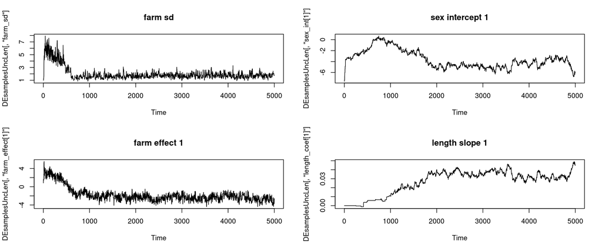

```r
par(mfrow = c(2,2))
ts.plot(DEsamplesUncLen[ , 'farm_sd'], main = 'farm sd')
ts.plot(DEsamplesUncLen[ , 'sex_int[1]'], main = 'sex intercept 1')
ts.plot(DEsamplesUncLen[ , 'farm_effect[1]'], main = 'farm effect 1')
ts.plot(DEsamplesUncLen[ , 'length_coef[1]'], main = 'length slope 1')
```

So here the main issue is the correlation of the {intercept,slope} pairs.

# Block sampling

After some trial and error, it turns out that modifying the defaults for the block sampler helps a huge amount and turns it from performing poorly to performing very well. One aspect of this is getting the relative scales of the parameters about right.

```r
modelBlock = nimbleModel(DEcode, constants = DEconstants_uncLen,
                         inits = DEinits_uncLen, data = DEdata)
```

```
## Defining model
```

```
## Building model
```

```
## Setting data and initial values
```

```
## Running calculate on model
##   [Note] Any error reports that follow may simply reflect missing values in model variables.
```

```
## Checking model sizes and dimensions
```

```r
cmodelBlock <- compileNimble(modelBlock)
```

```
## Compiling
##   [Note] This may take a minute.
##   [Note] Use 'showCompilerOutput = TRUE' to see C++ compilation details.
```

```r
mcmcConfBlock <- configureMCMC(modelBlock)
```

```
## ===== Monitors =====
## thin = 1: farm_sd, length_coef, sex_int
## ===== Samplers =====
## RW sampler (29)
##   - sex_int[]  (2 elements)
##   - length_coef[]  (2 elements)
##   - farm_sd
##   - farm_effect[]  (24 elements)
```

```r
mcmcConfBlock$removeSamplers(c('sex_int','length_coef'))

# Add RW_block samplers, modifying adaptation behavior.
mcmcConfBlock$addSampler(target = c('sex_int[1]', 'length_coef[1]'),
                 type = "RW_block",
                 control = list(propCov = diag(c(.1, .01)), adaptInterval = 20,
                                adaptFactorExponent = 0.25))
```

```
##   [Note] Assigning an RW_block sampler to nodes with very different scales can result in low MCMC efficiency.  If all nodes assigned to RW_block are not on a similar scale, we recommend providing an informed value for the "propCov" control list argument, or using the AFSS sampler instead.
```

```r
mcmcConfBlock$addSampler(target = c('sex_int[2]', 'length_coef[2]'),
                 type = "RW_block",
                 control = list(propCov = diag(c(.1, .01)), adaptInterval = 20,
                                adaptFactorExponent = 0.25))
```

```
##   [Note] Assigning an RW_block sampler to nodes with very different scales can result in low MCMC efficiency.  If all nodes assigned to RW_block are not on a similar scale, we recommend providing an informed value for the "propCov" control list argument, or using the AFSS sampler instead.
```

```r
mcmcConfBlock$addMonitors('farm_effect')
```

```
## thin = 1: farm_effect, farm_sd, length_coef, sex_int
```

# Block sampling (cont’d)

```r
mcmcBlock <- buildMCMC(mcmcConfBlock)
cmcmcBlock <- compileNimble(mcmcBlock, project = modelBlock)
```

```
## Compiling
##   [Note] This may take a minute.
##   [Note] Use 'showCompilerOutput = TRUE' to see C++ compilation details.
```

```r
time_block <- system.time(DEsamplesBlock <- runMCMC(cmcmcBlock, niter = 11000, nburnin = 1000))
```

```
## running chain 1...
```

```
## |-------------|-------------|-------------|-------------|
## |-------------------------------------------------------|
```

```r
cat("Sampling time: ", time_block[3], "seconds.\n")
```

```
## Sampling time:  1.348 seconds.
```

```r
hyperParams <- sort(modelBlock$getNodeNames(topOnly = TRUE))
effectiveSize(DEsamplesBlock) / time_block[3]
```

```
##  farm_effect[1]  farm_effect[2]  farm_effect[3]  farm_effect[4]  farm_effect[5]
##       218.05886       184.86044        94.23906       949.93919        67.68039
##  farm_effect[6]  farm_effect[7]  farm_effect[8]  farm_effect[9] farm_effect[10]
##      1370.69198       269.91476       228.30253       131.88671       150.75955
## farm_effect[11] farm_effect[12] farm_effect[13] farm_effect[14] farm_effect[15]
##        42.54435        95.59128       117.90174       348.73354       115.82040
## farm_effect[16] farm_effect[17] farm_effect[18] farm_effect[19] farm_effect[20]
##       584.50440       169.11352       354.99387       708.47374       152.80883
## farm_effect[21] farm_effect[22] farm_effect[23] farm_effect[24]         farm_sd
##       602.66967       128.59445       479.77218       737.94423       503.22976
##  length_coef[1]  length_coef[2]      sex_int[1]      sex_int[2]
##       674.38136       644.22571       567.33303       604.13467
```

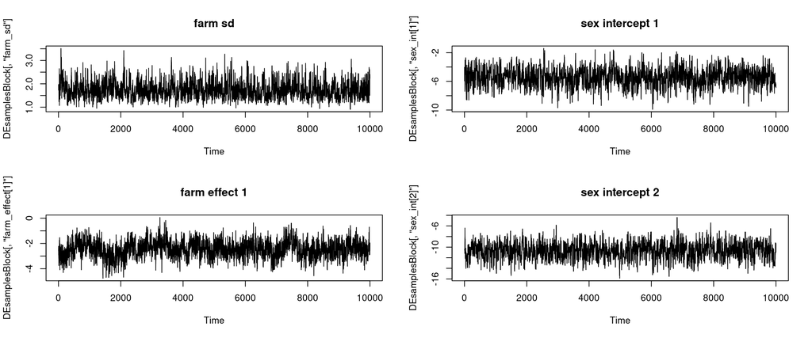

```r
par(mfrow = c(2,2))
ts.plot(DEsamplesBlock[ , 'farm_sd'], main = 'farm sd')
ts.plot(DEsamplesBlock[ , 'sex_int[1]'], main = 'sex intercept 1')
ts.plot(DEsamplesBlock[ , 'farm_effect[1]'], main = 'farm effect 1')
ts.plot(DEsamplesBlock[ , 'sex_int[2]'], main = 'sex intercept 2')
```

So the blocking helps a lot, though the farm effects show some oscillations. (A longer run looks fine.)

That was primarily intended as an illustration since we could simply center the covariates to address the intercept-slope correlation, but it looks like it could be a big improvement. We’d need to look further at the random effects.

# HMC: setup

Let’s consider HMC. The standard advice with random effects is to use a non-centered parameterization, which basically means writing out things like $x \sim N(\mu, \sigma)$ as $x = \mu + \sigma z$ for $z \sim N(0,1)$.

The original code did use non-centering in terms of the mean, so it’s already using a partially non-centered parameterization. But it didn’t use non-centering in terms of the `farm_sd` parameter. So we’ll modify the code a bit:

```r
library(nimbleHMC)

DEcode_hmc <- nimbleCode({
  for(i in 1:2) {
    # Priors for intercepts and length coefficients for sex = 1 (male), 2 (female)
    sex_int[i] ~ dnorm(0, sd = 1000)
    length_coef[i] ~ dnorm(0, sd = 1000)
  }

  # Priors for farm random effects and their standard deviation.
  farm_sd ~ dunif(0, 20)
  for(i in 1:num_farms) {
    farm_effect[i] ~ dnorm(0, sd = 1)
  }

  # logit link and Bernoulli data probabilities
  for(i in 1:num_animals) {
    logit(disease_probability[i]) <-
      sex_int[ sex[i] ] +
      length_coef[ sex[i] ]*length[i] +
      farm_sd * farm_effect[ farm_ids[i] ]
    Ecervi_01[i] ~ dbern(disease_probability[i])
  }
})
```

# HMC: setup (cont’d)

Configuring the HMC sampler:

```r
modelHMC <- nimbleModel(DEcode_hmc, constants = DEconstants,
              inits = DEinits, data = DEdata, buildDerivs = TRUE)
```

```
## Defining model
```

```
## Building model
```

```
## Setting data and initial values
```

```
## Running calculate on model
##   [Note] Any error reports that follow may simply reflect missing values in model variables.
```

```
## Checking model sizes and dimensions
```

```r
cmodelHMC <- compileNimble(modelHMC)
```

```
## Compiling
##   [Note] This may take a minute.
##   [Note] Use 'showCompilerOutput = TRUE' to see C++ compilation details.
```

```r
hmc <- buildHMC(modelHMC)
```

```
## ===== Monitors =====
## thin = 1: farm_effect, farm_sd, length_coef, sex_int
## ===== Samplers =====
## NUTS sampler (1)
##   - sex_int[1], sex_int[2], length_coef[1], length_coef[2], farm_sd, farm_effect[1], farm_effect[2], farm_effect[3], farm_effect[4], farm_effect[5], farm_effect[6], farm_effect[7], farm_effect[8], farm_effect[9], farm_effect[10], farm_effect[11], farm_effect[12], farm_effect[13], farm_effect[14],…
```

```r
cHMC <- compileNimble(hmc, project = modelHMC)
```

```
## Compiling
##   [Note] This may take a minute.
##   [Note] Use 'showCompilerOutput = TRUE' to see C++ compilation details.
```

# HMC: results

```r
time_hmc <- system.time(DEsamplesHMC <- runMCMC(cHMC, niter = 11000, nburnin = 1000))
```

```
## running chain 1...
```

```
##   [Note] NUTS sampler (nodes: sex_int[1], sex_int[2], length_coef[1], length_coef[2], farm_sd, farm_effect[1], farm_effect[2], ...) is using 1000 warmup iterations.
##          Since `warmupMode` is 'default' and `nburnin` > 0,
##          the number of warmup iterations is equal to `nburnin`.
##          The burnin samples will be discarded, and all samples returned will be post-warmup.
## |-------------|-------------|-------------|-------------|
## |-------------------------------------------------------|
```

```r
cat("Sampling time: ", time_hmc[3], "seconds.\n")
```

```
## Sampling time:  40.27 seconds.
```

```r
effectiveSize(DEsamplesHMC) / time_hmc[3]
```

```
##  farm_effect[1]  farm_effect[2]  farm_effect[3]  farm_effect[4]  farm_effect[5]
##        75.97988        96.10235        76.98141       188.75322        58.30660
##  farm_effect[6]  farm_effect[7]  farm_effect[8]  farm_effect[9] farm_effect[10]
##       256.76426        83.56106       108.84113        65.66086        95.95793
## farm_effect[11] farm_effect[12] farm_effect[13] farm_effect[14] farm_effect[15]
##        46.93615        65.81115        77.07633        91.64974        68.25879
## farm_effect[16] farm_effect[17] farm_effect[18] farm_effect[19] farm_effect[20]
##       126.22458        69.67814       102.02560       221.24537       103.77114
## farm_effect[21] farm_effect[22] farm_effect[23] farm_effect[24]         farm_sd
##       168.54042        80.02486       125.86538       173.10925        49.28270
##  length_coef[1]  length_coef[2]      sex_int[1]      sex_int[2]
##       248.32381       234.43340        39.13847        43.58232
```

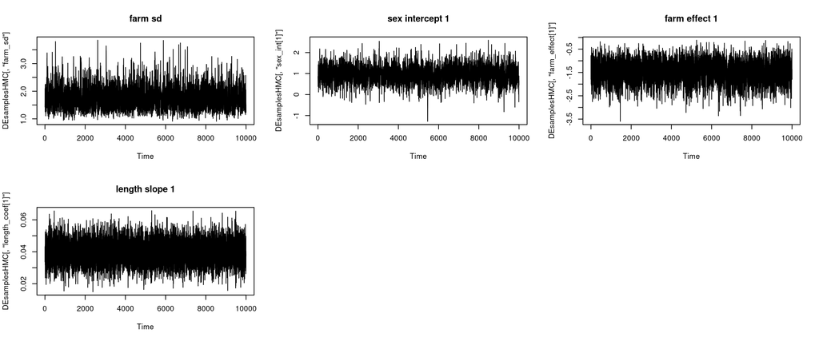

```r
par(mfrow = c(2,3))
ts.plot(DEsamplesHMC[ , 'farm_sd'], main = 'farm sd')
ts.plot(DEsamplesHMC[ , 'sex_int[1]'], main = 'sex intercept 1')
ts.plot(DEsamplesHMC[ , 'farm_effect[1]'], main = 'farm effect 1')
ts.plot(DEsamplesHMC[ , 'length_coef[1]'], main = 'length slope 1')
```

That mixes well on a per iteration basis, but notice that it took a lot more time (40 seconds) compared to a few seconds for our previous MCMCs) to get the same number of samples. So adjusted for computation time, the samplers seem fairly comparable, albeit without deep investigation here.

# Think like a graph: when to vectorize

Vectorizing some calculations:

- Can make code more compact.
- Can make model and MCMC building and compiling faster (fewer nodes).
- Can improve MCMC efficiency, but sometimes not by much (less looping over nodes).
- Can hurt MCMC efficiency if done in the wrong places (if unneeded dependencies are introduced).

```r
code <- nimbleCode({
  intercept ~ dnorm(0, sd = 1000)
  slope ~ dnorm(0, sd = 1000)
  sigma ~ dunif(0, 100)
  predicted.y[1:4] <- intercept + slope * x[1:4] # vectorized node
  for(i in 1:4) {
    y[i] ~ dnorm(predicted.y[i], sd = sigma)
  }
})
model <- nimbleModel(code, data = list(y = rnorm(4)))
```

```
## Defining model
```

```
## Building model
```

```
## Setting data and initial values
```

```
## Running calculate on model
##   [Note] Any error reports that follow may simply reflect missing values in model variables.
```

```
## Checking model sizes and dimensions
```

```
##   [Note] This model is not fully initialized. This is not an error.
##          To see which variables are not initialized, use model$initializeInfo().
##          For more information on model initialization, see help(modelInitialization).
```

```r
model$getDependencies('slope')
```

```
## [1] "slope"            "predicted.y[1:4]" "y[1]"             "y[2]"
## [5] "y[3]"             "y[4]"
```

Here sampling of `slope` (and `intercept`) will probably be a bit more efficient because of the vectorized definition of `predicted.y`, since all observations depend on `slope` (and `intercept`).

We avoid some overhead by having one `predicted.y[1:4]` node rather than four `predicted.y[1], ..., predicted.y[4]` nodes.

Another (manual) step would be to create a user-defined vectorized `dnorm` distribution so `y[1:4]` is a vector node.

# Think like a graph: when not to vectorize

However, if `x[2]` (and the other ’x’s) were a scalar parameter (in this case a random effect), vectorization is likely a bad idea.

Any update for `x[2]` will calculate `predicted.y[1:4]` and `y[1],...,y[4]` when only `predicted.y[2]` and `y[2]` need to be calculated.

```r
code <- nimbleCode({
  intercept ~ dnorm(0, sd = 1000)
  slope ~ dnorm(0, sd = 1000)
  sigma ~ dunif(0, 100)
  predicted.y[1:4] <- intercept + slope * x[1:4] # vectorized node
  for(i in 1:4) {
    x[i] ~ dnorm(0, 1)   # scalar random effects
    y[i] ~ dnorm(predicted.y[i], sd = sigma)
  }
})
model <- nimbleModel(code, data = list(y = rnorm(4)))
```

```
## Defining model
```

```
## Building model
```

```
## Setting data and initial values
```

```
## Running calculate on model
##   [Note] Any error reports that follow may simply reflect missing values in model variables.
```

```
## Checking model sizes and dimensions
```

```
##   [Note] This model is not fully initialized. This is not an error.
##          To see which variables are not initialized, use model$initializeInfo().
##          For more information on model initialization, see help(modelInitialization).
```

```r
model$getDependencies('x[2]')
```

```
## [1] "x[2]"             "predicted.y[1:4]" "y[1]"             "y[2]"
## [5] "y[3]"             "y[4]"
```

In this case, vectorization has made more dependencies for `x[2]` than should be necessary. This would result in wasted computation during MCMC sampling.